# 土地利用、人口结构、地价和生物多样性

康杰锋

## 引言

本文主要是关于土地利用、社会经济因子和生物多样性的关系，要讨论的主要问题是城市设计对城市绿色空间的影响和环境公平。

在先行研究中，除了土地利用等景观要素与生物多样性的关系，还有很多研究聚焦社会经济要素和生物多样性的关系。后者的结果表明，在很多城市中，存在”luxury effect”，其实就是环境不平等在生物多样性方面的体现：收入越高的居住区，往往生物多样性也越高。但是这个结果可能因城市设计、人们的居住选择、文化而有所不同。本文综合了**景观要素和社会经济要素，探究城市生物多样性的成因或后果。**

本研究的响应变量为各种生物多样性指标，包括：乔木的abundance、richness，灌木的abundance、richness。至于Shannon指数是否纳入分析，**仍需要讨论**，因为3个指数可能会让写作变得非常复杂。

解释变量包括：（1）景观变量，为样地中各类土地覆盖的百分比，包括低层居住用地、中高层居住用地、交通用地、农业用地、公园等等；（2）社会变量，为人口结构，包括0-14岁、15-64岁、65岁以上、75岁以上、85岁以上人口占比；（3）经济变量，采用了地价。

我先用皮尔森相关简单看了各个响应变量和各解释变量的关系，然后对每一个响应变量～解释变量组都构建了多个一般线性模型（GLM），筛选出最佳回归模型，再对变量进行分析。

## 相关分析

从下面的相关图可以看出，各个解释变量对各响应变量的效应比较一致。

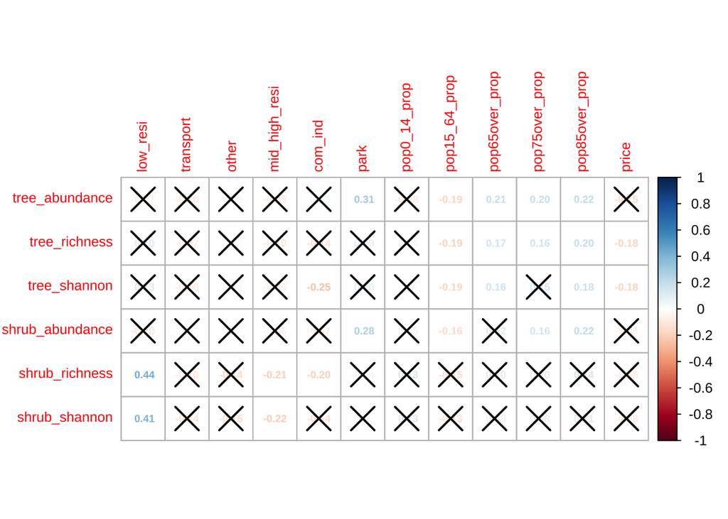

```r
GetCorrplot(
  st_drop_geometry(qua_bd_var)[bd_index],
  st_drop_geometry(qua_bd_var)[c(land_cover_var, pop_var, "price")]
)
```

## GLM模型

当然，相关分析仅考虑了一对变量之间的关系，而没有考虑其他变量的影响，因此我们还需要做回归模型分析。回归分析的首要问题是如何选入变量。在本研究中，我们对每个响应变量都测试了所有解释变量组合的模型效果。对于每个被测试的模型，有一个AIC值，AIC值和模型解释变量数量以及模型的拟合程度有关。通常认为AIC越小，模型越好。

下面是筛选出来的最佳模型，每一行是一个模型：

```r
lapply(
  bd_index[c(1, 2, 4, 5)], function(x) {
    get_best_glm(x, c(land_cover_var, pop_var, "price"))
  }
) %>%
  lapply(function(x) select(x, model_id, my_formula, aic))
```

```
## Morgan-Tatar search since family is non-gaussian.
## Morgan-Tatar search since family is non-gaussian.
## Morgan-Tatar search since family is non-gaussian.
## Morgan-Tatar search since family is non-gaussian.
```

```
## [[1]]
## # A tibble: 5 × 3
##   model_id my_formula                                                             aic
##      <int> <chr>                                                                <dbl>
## 1        1 tree_abundance ~ mid_high_resi + com_ind + park + pop65over_prop + … 1338.
## 2        2 tree_abundance ~ transport + mid_high_resi + com_ind + park + pop65… 1338.
## 3        3 tree_abundance ~ low_resi + other + com_ind + park + pop65over_prop… 1338.
## 4        4 tree_abundance ~ low_resi + com_ind + park + pop65over_prop + pop75… 1338.
## 5        5 tree_abundance ~ com_ind + park + pop65over_prop + pop75over_prop +… 1338.
##
## [[2]]
## # A tibble: 5 × 3
##   model_id my_formula                                                             aic
##      <int> <chr>                                                                <dbl>
## 1        1 tree_richness ~ transport + mid_high_resi + com_ind + pop15_64_prop…  740.
## 2        2 tree_richness ~ mid_high_resi + com_ind + pop15_64_prop + pop75over…  741.
## 3        3 tree_richness ~ transport + mid_high_resi + com_ind + pop15_64_prop…  742.
## 4        4 tree_richness ~ low_resi + transport + other + mid_high_resi + com_…  742.
## 5        5 tree_richness ~ transport + mid_high_resi + com_ind + pop65over_pro…  742.
##
## [[3]]
## # A tibble: 5 × 3
##   model_id my_formula                                                             aic
##      <int> <chr>                                                                <dbl>
## 1        1 shrub_abundance ~ park + pop0_14_prop + pop85over_prop               3781.
## 2        2 shrub_abundance ~ other + park + pop0_14_prop + pop85over_prop       3782.
## 3        3 shrub_abundance ~ low_resi + park + pop0_14_prop + pop85over_prop    3782.
## 4        4 shrub_abundance ~ park + pop0_14_prop + pop15_64_prop + pop85over_p… 3782.
## 5        5 shrub_abundance ~ mid_high_resi + park + pop0_14_prop + pop85over_p… 3783.
##
## [[4]]
## # A tibble: 5 × 3
##   model_id my_formula                                                             aic
##      <int> <chr>                                                                <dbl>
## 1        1 shrub_richness ~ low_resi + mid_high_resi + com_ind + pop0_14_prop …  923.
## 2        2 shrub_richness ~ low_resi + mid_high_resi + com_ind + pop0_14_prop …  923.
## 3        3 shrub_richness ~ low_resi + park + pop0_14_prop + pop85over_prop      923.
## 4        4 shrub_richness ~ low_resi + mid_high_resi + com_ind + park + pop0_1…  924.
## 5        5 shrub_richness ~ low_resi + mid_high_resi + com_ind + pop0_14_prop …  924.
```

对于每个模型，我们主要关注estimate（表示解释变量和响应变量之间的正负关系）和p值（表示这种关系是否显著），因此，我提取了上面每个模型所涉及的解释变量的estimate和p值：

```r
lapply(
  bd_index[c(1, 2, 4, 5)], function(x) {
    get_best_glm(x, c(land_cover_var, pop_var, "price")) %>%
      get_glm_est_p() %>%
      filter(var != "(Intercept)") %>%
      select(model_id, var, estimate, p)
  }
)
```

```
## Morgan-Tatar search since family is non-gaussian.
## Morgan-Tatar search since family is non-gaussian.
## Morgan-Tatar search since family is non-gaussian.
## Morgan-Tatar search since family is non-gaussian.
```

```
## [[1]]
## # A tibble: 36 × 4
##    model_id var                estimate      p
##       <int> <chr>                 <dbl>  <dbl>
##  1        1 mid_high_resi  -0.276       0.364
##  2        1 com_ind         0.469       0.259
##  3        1 park            0.753       0.0166
##  4        1 pop65over_prop  3.23        0.128
##  5        1 pop75over_prop -6.80        0.0978
##  6        1 pop85over_prop 10.3         0.0433
##  7        1 price          -0.000000718 0.0146
##  8        2 transport      -0.213       0.486
##  9        2 mid_high_resi  -0.316       0.308
## 10        2 com_ind         0.408       0.333
## # ℹ 26 more rows
##
## [[2]]
## # A tibble: 38 × 4
##    model_id var                estimate        p
##       <int> <chr>                 <dbl>    <dbl>
##  1        1 transport      -0.410       0.0765
##  2        1 mid_high_resi  -0.372       0.114
##  3        1 com_ind        -0.720       0.0251
##  4        1 pop15_64_prop  -2.36        0.0774
##  5        1 pop75over_prop -3.08        0.112
##  6        1 pop85over_prop  6.72        0.0535
##  7        1 price          -0.000000766 0.000727
##  8        2 mid_high_resi  -0.302       0.192
##  9        2 com_ind        -0.639       0.0449
## 10        2 pop15_64_prop  -2.38        0.0752
## # ℹ 28 more rows
##
## [[3]]
## # A tibble: 19 × 4
##    model_id var            estimate     p
##       <int> <chr>             <dbl> <dbl>
##  1        1 park             0.987      0
##  2        1 pop0_14_prop     5.36       0
##  3        1 pop85over_prop   5.77       0
##  4        2 other            0.147      0
```

[output cut: 16 more lines]

```
## [[4]]
## # A tibble: 28 × 4
##    model_id var            estimate          p
##       <int> <chr>             <dbl>      <dbl>
##  1        1 low_resi          0.687 0.00000994
##  2        1 mid_high_resi    -0.264 0.214
##  3        1 com_ind          -0.416 0.113
##  4        1 pop0_14_prop      1.90  0.141
##  5        1 pop85over_prop    3.69  0.0292
##  6        2 low_resi          0.679 0.0000136
##  7        2 mid_high_resi    -0.280 0.190
##  8        2 com_ind          -0.424 0.107
##  9        2 pop0_14_prop      1.77  0.176
## 10        2 pop15_64_prop    -0.574 0.495
## # ℹ 18 more rows
```

为了方便对比，我把各个模型的estimate和p值都画出来了。下面图中的每个有颜色的格子表示一个模型中的一个解释变量，例如，左上角第一行是shrub_abundance的5个最佳模型之一，其中mid_high_resi、park、pop0_14_prop、pop_85_over_prop是彩色的，意思是这个模型中包含了这些变量；其中，红色表示这个变量和shrub_abundance是负向相关的，而绿色则是正向相关的；格子里的数字则是p值。各个模型的结果数值见后面附录。

```
## Morgan-Tatar search since family is non-gaussian.
## Morgan-Tatar search since family is non-gaussian.
## Morgan-Tatar search since family is non-gaussian.
## Morgan-Tatar search since family is non-gaussian.
```

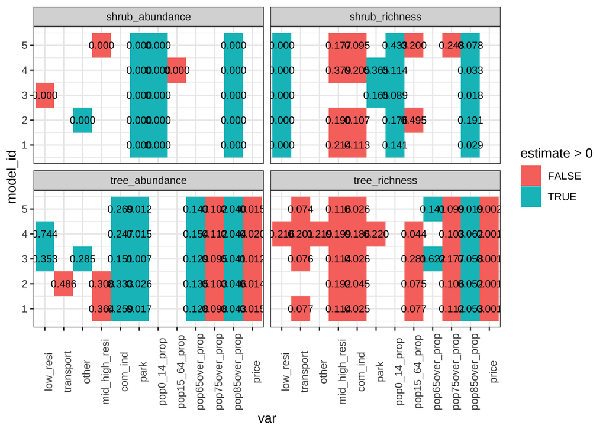

```r
lapply(
  bd_index[c(1, 2, 4, 5)], function(x) {
    get_best_glm(x, c(land_cover_var, pop_var, "price")) %>%
      get_glm_est_p()
  }
) %>%
  bind_rows() %>%
  filter(var != "(Intercept)") %>%
  mutate(var = factor(var, levels = c(land_cover_var, pop_var, "price"))) %>%
  ggplot(aes(var, model_id)) +
  geom_tile(aes(fill = estimate > 0)) +
  geom_text(aes(label = sprintf("%.3f", p)), size = 3) +
  theme_bw() +
  theme(axis.text.x = element_text(angle = 90)) +
  facet_wrap(.~ index)
```

## 附录

```r
lapply(
  bd_index[c(1, 2, 4, 5)], function(x) {
    get_best_glm(x, c(land_cover_var, pop_var, "price")) %>%
      get_glm_est_p()
  }
) %>%
  bind_rows() %>%
  filter(var != "(Intercept)") %>%
  select(-t_value, -z_value) %>%
  knitr::kable() %>%
  kableExtra::kable_styling()
```

```
## Morgan-Tatar search since family is non-gaussian.
## Morgan-Tatar search since family is non-gaussian.
## Morgan-Tatar search since family is non-gaussian.
## Morgan-Tatar search since family is non-gaussian.
```

| index | model_id | var | estimate | std_error | p |
| --- | --- | --- | --- | --- | --- |
| tree_abundance | 1 | mid_high_resi | -0.2756038 | 0.3025613 | 0.3638797 |
| tree_abundance | 1 | com_ind | 0.4693721 | 0.4139479 | 0.2587374 |
| tree_abundance | 1 | park | 0.7528712 | 0.3105616 | 0.0165896 |
| tree_abundance | 1 | pop65over_prop | 3.2254069 | 2.1080656 | 0.1282181 |
| tree_abundance | 1 | pop75over_prop | -6.7963160 | 4.0782270 | 0.0978052 |
| tree_abundance | 1 | pop85over_prop | 10.3412603 | 5.0716168 | 0.0432874 |
| tree_abundance | 1 | price | -0.0000007 | 0.0000003 | 0.0145663 |
| tree_abundance | 2 | transport | -0.2133512 | 0.3053038 | 0.4858101 |
| tree_abundance | 2 | mid_high_resi | -0.3159889 | 0.3088883 | 0.3080534 |
| tree_abundance | 2 | com_ind | 0.4076228 | 0.4195656 | 0.3329338 |
| tree_abundance | 2 | park | 0.7133326 | 0.3161657 | 0.0255859 |
| tree_abundance | 2 | pop65over_prop | 3.1780568 | 2.1139024 | 0.1349548 |
| tree_abundance | 2 | pop75over_prop | -6.7108146 | 4.0892924 | 0.1029960 |
| tree_abundance | 2 | pop85over_prop | 10.2612240 | 5.0855795 | 0.0455054 |
| tree_abundance | 2 | price | -0.0000007 | 0.0000003 | 0.0143220 |
| tree_abundance | 3 | low_resi | 0.2336286 | 0.2508949 | 0.3533403 |
| tree_abundance | 3 | other | 0.3296509 | 0.3074124 | 0.2853859 |
| tree_abundance | 3 | com_ind | 0.6442613 | 0.4465329 | 0.1512767 |
| tree_abundance | 3 | park | 0.9687877 | 0.3534081 | 0.0069075 |
| tree_abundance | 3 | pop65over_prop | 3.2298890 | 2.1168416 | 0.1292825 |
| tree_abundance | 3 | pop75over_prop | -6.8746693 | 4.0939529 | 0.0953072 |
| tree_abundance | 3 | pop85over_prop | 10.5044844 | 5.0878724 | 0.0407791 |
| tree_abundance | 3 | price | -0.0000008 | 0.0000003 | 0.0120494 |
| tree_abundance | 4 | low_resi | 0.0707228 | 0.2163121 | 0.7441853 |
| tree_abundance | 4 | com_ind | 0.5023069 | 0.4324660 | 0.2473759 |
| tree_abundance | 4 | park | 0.8240226 | 0.3352575 | 0.0151713 |
| tree_abundance | 4 | pop65over_prop | 3.0439886 | 2.1226312 | 0.1537371 |
| tree_abundance | 4 | pop75over_prop | -6.5747886 | 4.1104840 | 0.1119129 |
| tree_abundance | 4 | pop85over_prop | 10.3438376 | 5.0980042 | 0.0443141 |
| tree_abundance | 4 | price | -0.0000007 | 0.0000003 | 0.0197107 |

[output cut: 91 more lines]